# An Ultra-Fast All-in-One FASTQ preprocessor

Wei Wang

10/26/2021

#### Package

Rfastp 1.4.0

# 1 Introduction

The Rfastp package provides an interface to the all-in-one preprocessing for FastQ files toolkit fastp(Chen et al. 2018).

# 2 Installation

Use the `BiocManager` package to download and install the package from Bioconductor as follows:

```r
if (!requireNamespace("BiocManager", quietly = TRUE))
    install.packages("BiocManager")
BiocManager::install("Rfastp")
```

If required, the latest development version of the package can also be installed from GitHub.

```r
BiocManager::install("remotes")
BiocManager::install("RockefellerUniversity/Rfastp")
```

Once the package is installed, load it into your R session:

```r
library(Rfastp)
```

# 3 FastQ Quality Control with rfastp

The package contains three example fastq files, corresponding to a single-end fastq file, a pair of paired-end fastq files.

```r
se_read1 <- system.file("extdata","Fox3_Std_small.fq.gz",package="Rfastp")
pe_read1 <- system.file("extdata","reads1.fastq.gz",package="Rfastp")
pe_read2 <- system.file("extdata","reads2.fastq.gz",package="Rfastp")
outputPrefix <- tempfile(tmpdir = tempdir())
```

## 3.1 a normal QC run for single-end fastq file.

Rfastp support multiple threads, set threads number by parameter `thread`.

```r
se_json_report <- rfastp(read1 = se_read1,
    outputFastq = paste0(outputPrefix, "_se"), thread = 4)
```

## 3.2 a normal QC run for paired-end fastq files.

```r
pe_json_report <- rfastp(read1 = pe_read1, read2 = pe_read2,
    outputFastq = paste0(outputPrefix, "_pe"))
```

## 3.3 merge paired-end fastq files after QC.

```r
pe_merge_json_report <- rfastp(read1 = pe_read1, read2 = pe_read2, merge = TRUE,
    outputFastq = paste0(outputPrefix, '_unpaired'),
    mergeOut = paste0(outputPrefix, "_merged.fastq.gz"))
```

## 3.4 UMI processing

### 3.4.1 a normal UMI processing for 10X Single-Cell library.

```r
umi_json_report <- rfastp(read1 = pe_read1, read2 = pe_read2,
    outputFastq = paste0(outputPrefix, '_umi1'), umi = TRUE, umiLoc = "read1",
    umiLength = 16)
```

### 3.4.2 Set a customized UMI prefix and location in sequence name.

```r
umi_json_report <- rfastp(read1 = pe_read1, read2 = pe_read2,
    outputFastq = paste0(outputPrefix, '_umi2'), umi = TRUE, umiLoc = "read1",
    umiLength = 16, umiPrefix = "#", umiNoConnection = TRUE,
    umiIgnoreSeqNameSpace = TRUE)
```

## 3.5 A QC example with customized cutoffs and adapter sequence.

Trim poor quality bases at 3’ end base by base with quality higher than 5; trim poor quality bases at 5’ end by a 29bp window with mean quality higher than 20; disable the polyG trimming, specify the adapter sequence for read1.

```r
clipr_json_report <- rfastp(read1 = se_read1,
    outputFastq = paste0(outputPrefix, '_clipr'),
    disableTrimPolyG = TRUE,
    cutLowQualFront = TRUE,
    cutFrontWindowSize = 29,
    cutFrontMeanQual = 20,
    cutLowQualTail = TRUE,
    cutTailWindowSize = 1,
    cutTailMeanQual = 5,
    minReadLength = 29,
    adapterSequenceRead1 = 'GTGTCAGTCACTTCCAGCGG'
)
```

## 3.6 multiple input files for read1/2 in a vector.

rfastq can accept multiple input files, and it will concatenate the input files into one and the run fastp.

```r
pe001_read1 <- system.file("extdata","splited_001_R1.fastq.gz",
    package="Rfastp")
pe002_read1 <- system.file("extdata","splited_002_R1.fastq.gz",
    package="Rfastp")
pe003_read1 <- system.file("extdata","splited_003_R1.fastq.gz",
    package="Rfastp")
pe004_read1 <- system.file("extdata","splited_004_R1.fastq.gz",
    package="Rfastp")
inputfiles <- c(pe001_read1, pe002_read1, pe003_read1, pe004_read1)
cat_rjson_report <- rfastp(read1 = inputfiles,
    outputFastq = paste0(outputPrefix, "_merged1"))
```

# 4 concatenate multiple fastq files.

## 4.1 catfastq concatenate all the input files into a new file.

```r
pe001_read2 <- system.file("extdata","splited_001_R2.fastq.gz",
    package="Rfastp")
pe002_read2 <- system.file("extdata","splited_002_R2.fastq.gz",
    package="Rfastp")
pe003_read2 <- system.file("extdata","splited_003_R2.fastq.gz",
    package="Rfastp")
pe004_read2 <- system.file("extdata","splited_004_R2.fastq.gz",
    package="Rfastp")
inputR2files <- c(pe001_read2, pe002_read2, pe003_read2, pe004_read2)
catfastq(output = paste0(outputPrefix,"_merged2_R2.fastq.gz"),
    inputFiles = inputR2files)
```

# 5 Generate report tables/plots

## 5.1 A data frame for the summary.

```r
dfsummary <- qcSummary(pe_json_report)
```

## 5.2 a ggplot2 object of base quality plot.

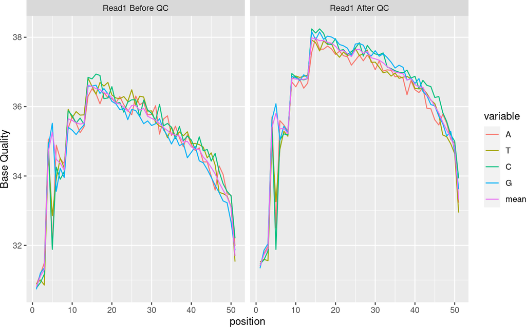

```r
p1 <- curvePlot(se_json_report)
p1
```

## 5.3 a ggplot2 object of GC Content plot.

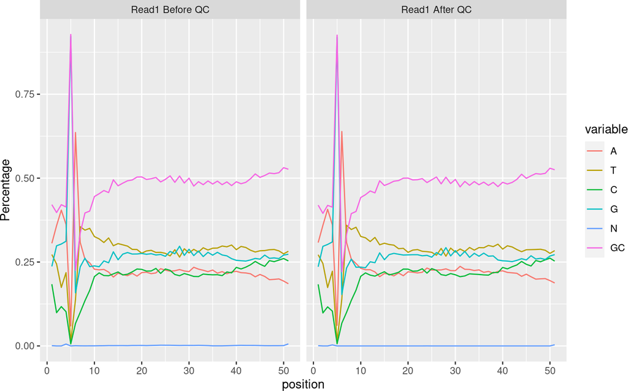

```r
p2 <- curvePlot(se_json_report, curve="content_curves")
p2
```

## 5.4 a data frame for the trimming summary.

```r
dfTrim <- trimSummary(pe_json_report)
```

# 6 Miscellaneous helper functions

usage of rfastp:

```r
?rfastp
```

usage of catfastq:

```r
?catfastq
```

usage of qcSummary:

```r
?qcSummary
```

usage of trimSummary:

```r
?trimSummary
```

usage of curvePlot:

```r
?curvePlot
```

# 7 Acknowledgments

Thank you to Ji-Dung Luo for testing/vignette review/critical feedback, Doug Barrows for critical feedback/vignette review and Ziwei Liang for their support. # Session info

[session information not shown]

# References

Chen, Shifu, Yanqing Zhou, Yaru Chen, and Jia Gu. 2018. “fastp: an ultra-fast all-in-one FASTQ preprocessor.” *Bioinformatics* 34 (17): i884–i890. https://doi.org/10.1093/bioinformatics/bty560.